# Chapter 1

# 1 Load libraries

```r
pacman::p_load(tidyverse,
               broom,
               ggbeeswarm,
               survminer,
               survival,
               tidytext,
               cowplot,
               factoextra)
```

# 2 A: Inter-species

## 2.1 Import data

Import metadata.

```r
metadata <-
  read_csv('../Raw/chap01_metadata.csv')
```

Import mortality data in long format in 3 species of *Acropora*.

```r
A_mortality_c <-
  list.files(path = '../Raw/',
             recursive = F,
             pattern = 'daily-survival.csv',
             full.names = T)

A_mortality_df <-
  read_csv(A_mortality_c,
           id = 'file_name') |>
  select(!1)
```

```
# A tibble: 2,440 × 9
   Species       `Start of experiment` Date      `Day elapsed` Colony Treatment
   <chr>         <chr>                 <chr>             <dbl> <chr>  <chr>
 1 A. digitifera 28-Oct-21             28-Oct-21             0 ADIG01 Control
 2 A. digitifera 28-Oct-21             28-Oct-21             0 ADIG02 Control
 3 A. digitifera 28-Oct-21             28-Oct-21             0 ADIG03 Control
 4 A. digitifera 28-Oct-21             28-Oct-21             0 ADIG04 Control
 5 A. digitifera 28-Oct-21             28-Oct-21             0 ADIG05 Control
 6 A. digitifera 28-Oct-21             28-Oct-21             0 ADIG06 Control
 7 A. digitifera 28-Oct-21             28-Oct-21             0 ADIG07 Control
 8 A. digitifera 28-Oct-21             28-Oct-21             0 ADIG08 Control
 9 A. digitifera 28-Oct-21             28-Oct-21             0 ADIG09 Control
10 A. digitifera 28-Oct-21             28-Oct-21             0 ADIG10 Control
# ℹ 2,430 more rows
# ℹ 3 more variables: `N fragment` <dbl>, `Bleached fragments` <dbl>,
#   `Healthy fragments` <dbl>
```

Export raw, compiled data.

```r
write_csv(A_mortality_df,
          file = '../Results/Tables/A_mortality_df.csv')
```

## 2.2 Clean data

Among the Acropora species, only *A. tenuis* showed mortality in the control tanks during exposure. These will not be included in further analyses, cutting the A. tenuis colonies that will be included to 25.

These colonies are: ATEN07, ATEN08, ATEN09, ATEN24, ATEN25.

```r
A1_mortality_unres_c <- c("ATEN07","ATEN08","ATEN09","ATEN24","ATEN25")

A_mortality_df <-
  A_mortality_df |>
  filter(!Colony %in% A1_mortality_unres_c)
```

Filter data to only include thermally challenged setups. Note that control tanks were only set to check that stress is not confounded by handling stress.

```r
A_mortality_heat_df <-
  A_mortality_df |>
  filter(Treatment == 'Heat-stressed')
```

## 2.3 Do stats

Before doing any plot-related work, set a color palette.

```r
color_species_c <- c("#294557","#558981","#C6BF88")
color_htol_c <- c("#B2182B", "#2166AC")
color_htol_int_c <- c("#B2182B","gray", "#2166AC")
```

Comparison of measures of central tendency was done at first but it was deemed that comparison of survival curves is more appropriate.

### 2.3.1 Kaplan-Meier

Shape data to be appropriate for survival curves analysis.

```r
A_mortality_km_df <-
  A_mortality_heat_df |>
  select(c(1,4,5,7:9))

# Make a tibble for A. millepora that extends to 13 days (for comparison with Adig)
A_mortality_amil_df <-
  A_mortality_km_df |>
  filter(Species == 'A. millepora') |>
  distinct(Colony,
           .keep_all = T) |>
  mutate('Days elapsed 11' = 11,
         'Days elapsed 12' = 12,
         'Days elapsed 13' = 13,
         `Healthy fragments` = NA) |>
  select(!`Day elapsed`) |>
  pivot_longer(cols = !c(1:5),names_to = 'Days',values_to = 'Day elapsed') |>
  select(!Days)

# Make a tibble for A. millepora that extends to 13 days (for comparison with Adig)
A_mortality_aten_df <-
  A_mortality_km_df |>
  filter(Species == 'A. tenuis') |>
  distinct(Colony,
           .keep_all = T) |>
  mutate('Days elapsed 11' = 11,
         'Days elapsed 12' = 12,
         'Days elapsed 13' = 13,
         `Healthy fragments` = NA) |>
  select(!`Day elapsed`) |>
  pivot_longer(cols = !c(1:5),names_to = 'Days',values_to = 'Day elapsed') |>
  select(!Days)

# Combine all tibbles
A_mortality_all_df <-
  A_mortality_km_df |>
  bind_rows(A_mortality_amil_df,
            A_mortality_aten_df)|>
  mutate(`Healthy fragments` = case_when(`Healthy fragments` == NA ~ 1,
                                         .default = `Healthy fragments`))
```

Make a dataframe that with status (censor).

```r
A_mortality_all_df <-
  A_mortality_all_df |>
  # Make a string, delimited by comma to make ID fragments
  rowwise() %>%
  mutate('Fragment ID' = paste0(Colony,
                                '_',
                                seq_len(`N fragment`),
                                collapse = ",")) %>%
  ungroup() %>%
  # Separate them
  separate(`Fragment ID`,
           into = paste0("Fragment ID_",
                         1:max(str_count(.$`Fragment ID`, ",")) + 1),
           sep = ",",
           remove = F,
           extra = 'merge') |>
  separate(`Fragment ID_8`,
           into = c('Fragment ID_9', 'Fragment ID_10'),
           sep = ",",
           remove = T) |>
  # Remove Fragment ID
  select(!`Fragment ID`) |>
  # Make tibble longer
  pivot_longer(cols = 7:14,
               values_to = 'Fragment ID',
               values_drop_na = T) |>
  select(!name) |>
  mutate('Fragment #' = str_sub(`Fragment ID`, -1, -1),
         'Fragment #' = as.numeric(`Fragment #`)) |>
  mutate(status = case_when(`Healthy fragments` == NA ~ 1,
                            `Healthy fragments` < `Fragment #` ~ 2,
                            .default = 1))
```

Export shaped tibble.

```r
write_csv(A_mortality_all_df,
          file = '../Results/Tables/A_mortality_all_km_df.csv')
```

Make plot.

```r
# Fit data
A_mortality_all_km <-
  survfit(Surv(`Day elapsed`, status) ~ Species, data = A_mortality_all_df)

# Plot data
A_mortality_all_km_p <-
  ggsurvplot(A_mortality_all_km,
             conf.int = T,
             data = A_mortality_all_df,
             palette = color_species_c,
             censor.shape = NA, ylim = c(.80, 1),
             size = 1.5,
             legend = 'right')
```

Export plot.

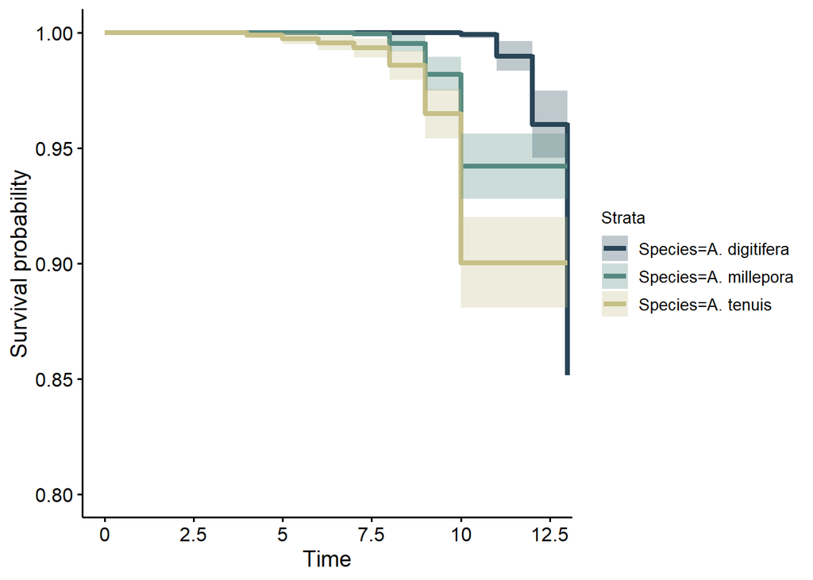

```r
ggsave('../Results/Figures/kaplan-meier.png',
       dpi = 900,
       width = 7000,
       height = 3000,
       units = "px")
```

Make a global log-rank test.

```r
A_mortality_km_glob_s <-
  surv_pvalue(A_mortality_all_km,
              data = A_mortality_all_df)
```

Export.

```r
write_csv(A_mortality_km_glob_s,
          '../Results/Tables/A_mortality_km_glob_s.csv')
```

Make a pairwise log-rank test.

```r
A_mortality_km_pair_s <-
  pairwise_survdiff(Surv(`Day elapsed`, status) ~ Species,
                    data = A_mortality_all_df,
                    p.adjust.method = 'BH') |>
  tidy()
```

Exrport.

```r
write_csv(A_mortality_km_pair_s,
          '../Results/Tables/A_mortality_km_pair_s.csv')
```

# 3 Inter-individual

## 3.1 B: Survival-based

### 3.1.1 Clean data

Shape the initially imported data. For this analysis, only the last day per species will be considered to get the proportion of fragment bleached at end of exposure (% survival).

```r
B_individual_mort_df <-
  A_mortality_heat_df |>
  filter(`Day elapsed` >= 10) |>
  filter(!(Species == 'A. digitifera' & `Day elapsed` >= 10 & `Day elapsed` < 13)) |>
  mutate('% fragments healthy' = `Healthy fragments`/`N fragment` * 100) |>
  group_by(Species) |>
  mutate(Colony = case_when(Species == 'A. digitifera' ~ paste0('D', str_sub(Colony,5,6)),
                            Species =='A. tenuis' ~ paste0('T', str_sub(Colony,5,6)),
                            Species == 'A. millepora' ~ paste0('M', str_sub(Colony,5,6)),
                            .default = Colony)) |>
  mutate('Proportion of fragments bleached, %' = 100 - `% fragments healthy`)
```

Rank.

```r
B_individual_mort_rank_df <-
  B_individual_mort_df |>
  group_by(Species) |>
  arrange(`Proportion of fragments bleached, %`, .by_group = TRUE) |>
  mutate(Ranking  = seq_along(Species),
         'Heat tolerance' = ifelse(`Proportion of fragments bleached, %` >= 50, "Low", "High"))
```

Export.

```r
B_individual_mort_rank_df |>
  write_csv('../Results/Tables/B_individual_mort_rank_df.csv')
```

### 3.1.2 Plot

Make a plot function.

```r
B_individual_mort_f <-
  function(x){
    x |>
      ggplot(aes(x = reorder(Colony, desc(`Proportion of fragments bleached, %`)),
                 y = `Proportion of fragments bleached, %`,
                 fill = `Heat tolerance`)) +
      geom_bar(stat = 'identity',
               alpha = 0.90) +
      facet_grid(cols = vars(Species),
                 scales = 'free',
                 space = 'free',
                 axes = 'all',
                 axis.labels = 'all') +
      scale_fill_manual(values = color_htol_c) +
      scale_y_continuous(limits = c(0,100),
                         expand = expansion(0, 0)) +
      theme(panel.grid = element_blank(),
            axis.title.x = element_blank(),
            strip.background = element_blank(),
            axis.line = element_line(),
            panel.background = element_rect(fill = '#F5F5F5'),
            panel.grid.major.y = element_line(colour = 'white',
                                              linewidth = 0.75),
            panel.grid.minor.y = element_line(colour = 'white',
                                              linewidth = 0.25),
            strip.text = element_text(face = 'italic'))
  }
```

Plot.

```r
B_individual_mort_all_p <-
  B_individual_mort_rank_df |>
  B_individual_mort_f()
```

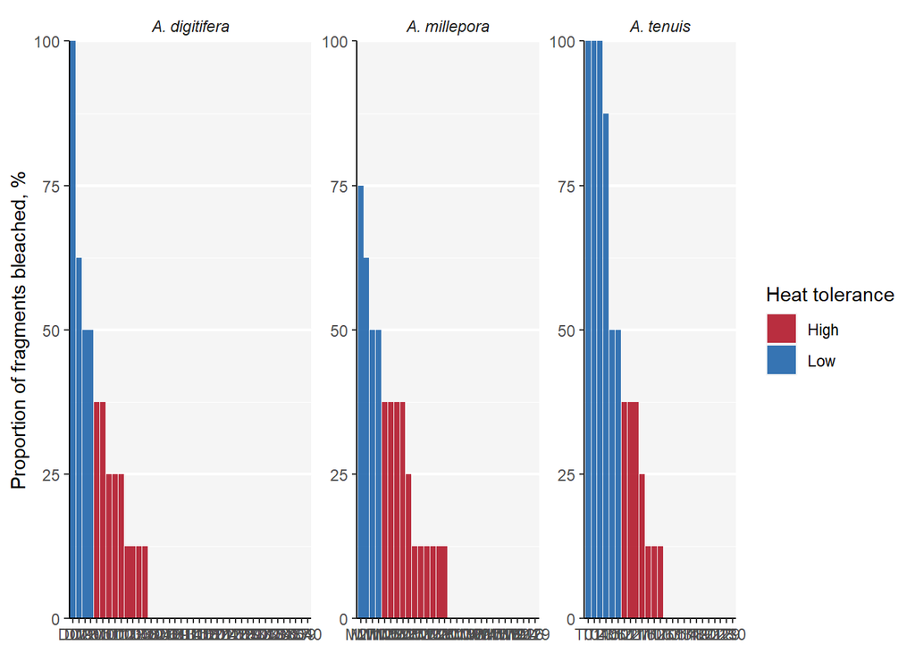

Export.

```r
ggsave(plot = B_individual_mort_all_p,
       filename = '../Results/Figures/individual-mort.png',
       dpi = 900,
       width = 25000,
       height = 2000,
       units = "px")
```

## 3.2 C: MIG

### 3.2.1 *A. digitifera*

Import pre-exposure MIG data.

```r
C_individual_mig_ad_pre_df <-
  read_csv('../Raw/chap01_adig_mig_pre.csv') |>
  mutate(Replicate = rep(c(1,2),
                         length.out = n()))
```

Import post-exposure MIG data.

```r
C_individual_mig_ad_post_df <-
  read_csv('../Raw/chap01_adig_mig_post.csv') |>
  mutate(Replicate = rep(c(1,2),
                         length.out = n()))
```

Merge.

```r
C_individual_mig_ad_df <-
  C_individual_mig_ad_pre_df |>
  left_join(C_individual_mig_ad_post_df,
            by = c('Colony ID',
                   'Tank ID',
                   'Treatment',
                   'Replicate'),
            suffix = c(".pre", ".post"))
```

Compute change.

```r
# Compute
C_individual_mig_ad_df <-
  C_individual_mig_ad_df |>
  mutate('% change' = (`Normalized mean gray value.post` - `Normalized mean gray value.pre`)/`Normalized mean gray value.pre` * 100)

# Clean
C_individual_mig_ad_df <-
  C_individual_mig_ad_df |>
  filter(Treatment == 'Heat-stressed') |>
  select(`Colony ID`, `% change`) |>
  mutate(`Colony ID` = str_replace(`Colony ID`, "ADIG", "D")) |>
  mutate(Species = 'A. digitifera')
```

### 3.2.2 *A. millepora*

Make a function to edit *A. millepora* data.

```r
C_individual_mig_f <-
  function(pre_path,
           post_path,
           species_id,
           recode,
           species){
    mig_pre_df <-
      read_csv(pre_path) |>
      mutate(Replicate = rep(c(1,2),
                             length.out = n()))
    mig_post_df <-
      read_csv(post_path) |>
      mutate(Replicate = rep(c(1,2),
                             length.out = n()))
    mig_merged <-
      mig_pre_df |>
        left_join(mig_post_df,
                  by = c('Colony ID',
                         'Tank ID',
                         'Treatment',
                         'Replicate'),
                  suffix = c(".pre", ".post"))
    mig_compute <-
      mig_merged |>
        mutate('% change' = (`Normalized mean gray value.post` - `Normalized mean gray value.pre`)/`Normalized mean gray value.pre` * 100)|>
      filter(Treatment == 'Heat-stressed') |>
      select(`Colony ID`, `% change`) |>
      left_join(metadata |> rename(`Colony ID` = `Untransformed ID`) |>
                  select(2,4),
                by = 'Colony ID') |>
      relocate(1,3) |>
      select(!1) |>
      rename('Colony ID' = `Transformed ID2`) |>
      mutate(Species = 'A. millepora')
  }
```

Import and edit.

```r
C_individual_mig_am_df <-
  C_individual_mig_f(pre_path = '../Raw/chap01_amil_mig_pre.csv',
                     post_path = '../Raw/chap01_amil_mig_post.csv',
                     species_id = 'AMIL',
                     recode = 'M',
                     species = 'A. millepora')
```

### 3.2.3 *A. tenuis*

Edit function for A. tenuis.

```r
C_individual_mig_f <-
  function(pre_path,
           post_path,
           species_id,
           recode,
           species){
    mig_pre_df <-
      read_csv(pre_path) |>
      mutate(Replicate = rep(c(1,2),
                             length.out = n()))
    mig_post_df <-
      read_csv(post_path) |>
      mutate(Replicate = rep(c(1,2),
                             length.out = n()))
    mig_merged <-
      mig_pre_df |>
        left_join(mig_post_df,
                  by = c('Colony ID',
                         'Tank ID',
                         'Treatment',
                         'Replicate'),
                  suffix = c(".pre", ".post"))
    mig_compute <-
      mig_merged |>
        mutate('% change' = (`Normalized mean gray value.post` - `Normalized mean gray value.pre`)/`Normalized mean gray value.pre` * 100)|>
      filter(Treatment == 'Heat-stressed') |>
      select(`Colony ID`, `% change`) |>
      mutate(`Colony ID` = str_replace(`Colony ID`, species_id, recode)) |>
      mutate(Species = species)
  }
```

Import and edit.

```r
C_individual_mig_at_df <-
  C_individual_mig_f(pre_path = '../Raw/chap01_aten_mig_pre.csv',
                     post_path = '../Raw/chap01_aten_mig_post.csv',
                     species_id = 'ATEN',
                     recode = 'T',
                     species = 'A. tenuis')
```

### 3.2.4 Merge dataframes

```r
# Merge
C_individual_mig_all_df <-
  bind_rows(C_individual_mig_ad_df,
            C_individual_mig_am_df,
            C_individual_mig_at_df)

# Make a df that will allow you to reorder and rank colonies based on MIG change averages
C_individual_mig_all_df <-
  C_individual_mig_all_df |>
  dplyr::group_by(`Colony ID`) |>
  drop_na() |>
  mutate(Mean = mean(`% change`)) |>
  ungroup()|>
  filter(!`Colony ID` %in% str_replace(A1_mortality_unres_c, 'ATEN','T'))

# Quick clean & ranking
C_individual_mig_all_2_df <-
  C_individual_mig_all_df |>
  group_by(Species) |>
  arrange(Mean, .by_group = TRUE) |>
  distinct(`Colony ID`,.keep_all = T) |>
  mutate(Ranking  = seq_along(Species)) |>  # Remove unclassified Ts
  mutate('Heat tolerance' = case_when(Species == 'A. digitifera' & Ranking <= 8 ~ 'High',
                                      Species == 'A. digitifera' & Ranking >= 33 ~ 'Low',
                                      Species == 'A. millepora' & Ranking <= 6 ~ 'High',
                                      Species == 'A. millepora' & Ranking >= 25 ~ 'Low',
                                      Species == 'A. tenuis' & Ranking <= 5 ~ 'High',
                                      Species == 'A. tenuis' & Ranking >= 21 ~ 'Low',
                                      .default = 'Intermediate'))
```

Export.

```r
write_csv(C_individual_mig_all_2_df,
          '../Results/Tables/C_individual_mig_rank_df.csv')
```

### 3.2.5 Plot

```r
C_individual_mig_all_p <-
  C_individual_mig_all_df |>
  left_join(C_individual_mig_all_2_df |> ungroup() |> select(1,6),
            by = 'Colony ID') |>
  mutate(`Colony ID` = reorder_within(`Colony ID`, desc(Mean), Species)) |>
  ggplot(aes(x = `Colony ID`,
             y = `% change`,
             fill = `Heat tolerance`,
             color = `Heat tolerance`)) +
  geom_quasirandom(size = 1,
                   alpha = 0.25,
                   method = "pseudorandom",
                   width = 0.2) +
  geom_hline(yintercept = 0,
             linetype = 'dashed',
             color = 'black',
             linewidth = 0.25) +
  stat_summary(fun = 'mean',
               size = 0.5) +
  facet_grid(cols = vars(Species),
             scales = 'free',
             space = 'free',
             axes = 'all',
             axis.labels = 'all') +
  scale_fill_manual(values = color_htol_int_c) +
  scale_color_manual(values = color_htol_int_c) +
  scale_x_reordered() +
  theme(panel.grid = element_blank(),
        axis.title.x = element_blank(),
        strip.background = element_blank(),
        axis.line = element_line(),
        panel.background = element_rect(fill = '#F5F5F5'),
        panel.grid.major.y = element_line(colour = 'white',
                                          linewidth = 0.75),
        panel.grid.minor.y = element_line(colour = 'white',
                                          linewidth = 0.25),
        strip.text = element_text(face = 'italic'))
```

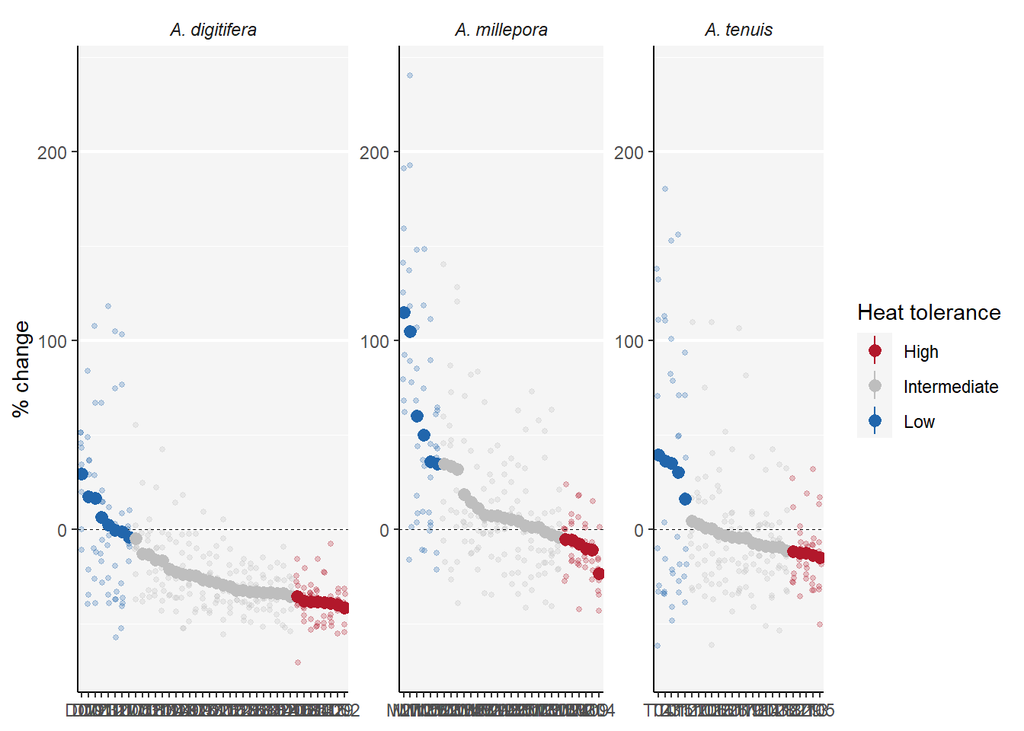

Export.

```r
ggsave(plot = C_individual_mig_all_p,
       filename = '../Results/Figures/individual-mig.png',
       dpi = 900,
       width = 25000,
       height = 3000,
       units = "px")
```

## 3.3 D: Survival + MIG

Make an additional dataset that combines proportion of fragments bleaching and MIG values to check possible changes in classification based on actual bleaching records and image analysis-derived data.

Combine datasets.

```r
D_individual_mort.mig_df <-
  B_individual_mort_rank_df |>
  ungroup() |>
  select(Colony, `Proportion of fragments bleached, %`) |>
  rename('Colony ID' = Colony) |>
  left_join(C_individual_mig_all_2_df |> select(c(1,3,4))) |>
  relocate(Species)
```

Make a function for min-max normalization.

```r
D_indiv_mort.mig_minmax_norm_f <-
  function(x){
    (x - min(x)) /(max(x) - min(x))
  }
```

Normalize proportion of fragments bleached and MIG values.

```r
D_individual_mort.mig_std_df <-
  D_individual_mort.mig_df |>
  group_by(Species) |>
  mutate(`Proportion of fragments bleached, %` = D_indiv_mort.mig_minmax_norm_f(`Proportion of fragments bleached, %`),
         Mean = D_indiv_mort.mig_minmax_norm_f(Mean),
         Combined = `Proportion of fragments bleached, %` + Mean)
```

Rank colonies based on combined standardized values.

```r
D_individual_mort.mig_std_df <-
  D_individual_mort.mig_std_df |>
  group_by(Species) |>
  arrange(Combined, .by_group = TRUE) |>
  mutate(Ranking  = seq_along(Species)) |>
  mutate('Heat tolerance' = case_when(Species == 'A. digitifera' & Ranking <= 8 ~ 'High',
                                      Species == 'A. digitifera' & Ranking >= 33 ~ 'Low',
                                      Species == 'A. millepora' & Ranking <= 6 ~ 'High',
                                      Species == 'A. millepora' & Ranking >= 25 ~ 'Low',
                                      Species == 'A. tenuis' & Ranking <= 5 ~ 'High',
                                      Species == 'A. tenuis' & Ranking >= 21 ~ 'Low',
                                      .default = 'Intermediate'))

# Export
D_individual_mort.mig_std_df |>
  write_csv('../Results/Tables/D_individual_mort.mig_rank_df.csv')
```

Plot.

```r
D_individual_mort.mig_std_p <-
  D_individual_mort.mig_std_df |>
  ggplot() +
  geom_bar(aes(x = reorder(`Colony ID`, desc(Combined)),
               y = `Proportion of fragments bleached, %`),
           stat = 'identity',
           alpha = 0.15) +
  geom_point(aes(x = reorder(`Colony ID`, desc(Combined)),
               y = Combined,
               fill = `Heat tolerance`),
           shape = 21,
           color = 'white',
           size = 4) +
  geom_point(aes(x = reorder(`Colony ID`, desc(Combined)),
                 y = Mean),
             size = 1,
             alpha = 0.15)  +
  facet_grid(cols = vars(Species),
             scales = 'free',
             space = 'free',
             axes = 'all',
             axis.labels = 'all') +
  scale_fill_manual(values = color_htol_int_c) +
  scale_y_continuous(limits = c(0,2.1),
                     expand = expansion(0, 0)) +
  theme(panel.grid = element_blank(),
        axis.title.x = element_blank(),
        strip.background = element_blank(),
        axis.line = element_line(),
        panel.background = element_rect(fill = '#F5F5F5'),
        panel.grid.major.y = element_line(colour = 'white',
                                          linewidth = 0.75),
        panel.grid.minor.y = element_line(colour = 'white',
                                          linewidth = 0.25),
        strip.text = element_text(face = 'italic'))
```

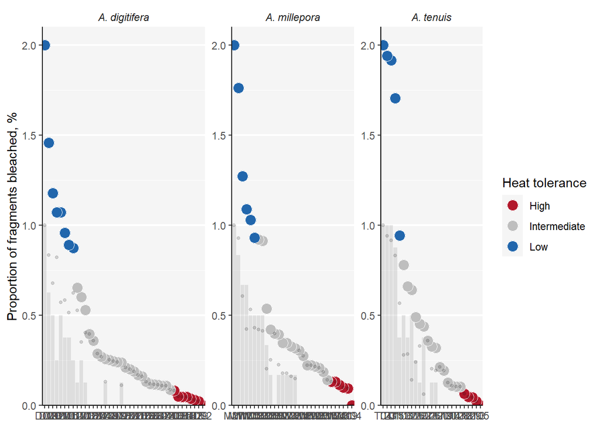

Export.

```r
ggsave(plot = D_individual_mort.mig_std_p,
       filename = '../Results/Figures/individual-mort.mig.png',
       dpi = 900,
       width = 25000,
       height = 3000,
       units = "px")
```

Make plot and add stats for correlation between mortality and MIG (rationale for adding standardized values).

```r
D1_individual_mort.mig_p <-
  D_individual_mort.mig_df |>
  ggscatter(x = 'Proportion of fragments bleached, %',
            y = 'Mean',
            add = "reg.line",
            conf.int = TRUE,
            alpha = 0.5,
            cor.method = 'spearman') +
  stat_cor() +
  labs(x = 'Proportion of  dead fragments (%)',
       y = 'Mean % MIG change') +
  facet_grid(cols = vars(Species),
             scales = 'free',
             space = 'free',
             axes = 'all',
             axis.labels = 'all') +
  theme(panel.grid = element_blank(),
        strip.background = element_blank(),
        axis.line = element_line(),
        panel.background = element_rect(fill = '#F5F5F5'),
        panel.grid.major.y = element_line(colour = 'white',
                                          linewidth = 0.75),
        panel.grid.minor.y = element_line(colour = 'white',
                                          linewidth = 0.25),
        strip.text = element_text(face = 'italic'))
```

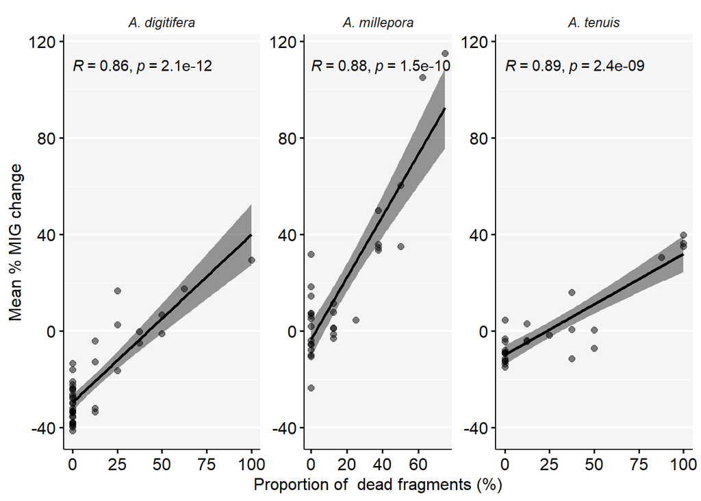

Export.

```r
ggsave(plot = D1_individual_mort.mig_p,
       filename = '../Results/Figures/individual-mort.mig-corr.png',
       dpi = 900,
       width = 10000,
       height = 4000,
       units = "px")
```

## 3.4 E: k-means

Make additional clustering metric to find support for the tolerance grouping based on phenotype ranking.

### 3.4.1 *A. digitifera*

```r
# Edit dataframe to get A. digitifera samples
E_individual_kmean_ad_m <-
  D_individual_mort.mig_df |>
  filter(Species == 'A. digitifera') |>
  select(!Species) |>
  column_to_rownames('Colony ID') |>
  as.matrix()

# Optimal cluster checking 1 (wss)
E_individual_kmean_ad_wss <-
  fviz_nbclust(E_individual_kmean_ad_m,
               kmeans,
               method = "wss",
               k.max = 10,
               linecolor = 'black') +
  theme(plot.title = element_blank(),
        panel.grid = element_blank(),
        strip.background = element_blank(),
        axis.line = element_line(),
        panel.background = element_rect(fill = '#F5F5F5'),
        panel.grid.major.y = element_line(colour = 'white',
                                          linewidth = 0.75),
        panel.grid.minor.y = element_line(colour = 'white',
                                          linewidth = 0.25))

# Optimal cluster checking 2 (gap)
E_individual_kmean_ad_gap <-
  fviz_nbclust(E_individual_kmean_ad_m,
               kmeans,
               method = "gap",
               nboot=200,
               k.max = 10,
               linecolor = 'black') +
  theme(plot.title = element_blank(),
        panel.grid = element_blank(),
        strip.background = element_blank(),
        axis.line = element_line(),
        panel.background = element_rect(fill = '#F5F5F5'),
        panel.grid.major.y = element_line(colour = 'white',
                                          linewidth = 0.75),
        panel.grid.minor.y = element_line(colour = 'white',
                                          linewidth = 0.25))

# Optimal cluster checking 3 (sillhouette)
E_individual_kmean_ad_sil <-
  fviz_nbclust(E_individual_kmean_ad_m,
               kmeans,
               method = "silhouette",
               k.max = 10,
               linecolor = 'black') +
  theme(plot.title = element_blank(),
        panel.grid = element_blank(),
        strip.background = element_blank(),
        axis.line = element_line(),
        panel.background = element_rect(fill = '#F5F5F5'),
        panel.grid.major.y = element_line(colour = 'white',
                                          linewidth = 0.75),
        panel.grid.minor.y = element_line(colour = 'white',
                                          linewidth = 0.25))

# Merge plots that check optimal # of clusters
E_individual_kmean_ad_opt_p <-
  plot_grid(E_individual_kmean_ad_wss,
            E_individual_kmean_ad_gap,
            E_individual_kmean_ad_sil,
            nrow = 1)

# Make a plot that shows clusters
E_individual_kmean_ad_p <-
  E_individual_kmean_ad_m |>
  kmeans(centers = 2) |>
  fviz_cluster(E_individual_kmean_ad_m,
               labelsize = 8,
               repel = T,
               ylab = '% change in MIG',
               xlab = 'Proportion of dead fragments (%)',
               shape = 16) +
  scale_fill_manual(values = rev(color_htol_c)) +
  scale_color_manual(values = rev(color_htol_c)) +
  coord_fixed() +
  theme(panel.grid = element_blank(),
        plot.title = element_blank(),
        legend.position = 'none',
        strip.background = element_blank(),
        axis.line = element_line(),
        panel.background = element_rect(fill = '#F5F5F5'),
        panel.grid.major.y = element_line(colour = 'white',
                                          linewidth = 0.75),
        panel.grid.minor.y = element_line(colour = 'white',
                                          linewidth = 0.25),
        panel.grid.major.x = element_line(colour = 'white',
                                          linewidth = 0.75),
        panel.grid.minor.x = element_line(colour = 'white',
                                          linewidth = 0.25))

# Extract clusters
E_individual_kmean_ad_df <-
  E_individual_kmean_ad_m |>
  kmeans(centers = 2) %>%
  .$cluster |>
  as.data.frame() |>
  rownames_to_column() |>
  rename(ColonyID = 1,
         Cluster = 2) |>
  mutate(HeatTolerance = if_else(Cluster == 1,
                                 'Low',
                                 'High'))

# Merge plots
E_individual_kmean_ad_all_p <-
  plot_grid(E_individual_kmean_ad_p,
            E_individual_kmean_ad_opt_p,
            ncol = 2,
            rel_widths = c(1,0.5))
```

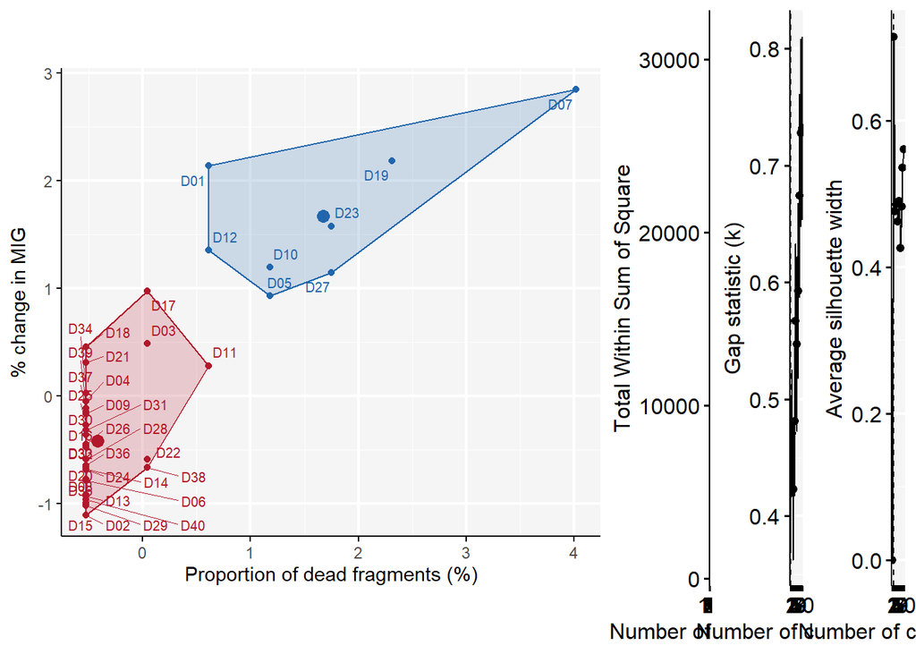

Export.

```r
ggsave(E_individual_kmean_ad_all_p,
       filename = '../Results/Figures/E_individual_kmean_ad_all_p.png',
       dpi = 900,
       width = 18000,
       height = 4000,
       units = "px")

E_individual_kmean_ad_df |>
  write_csv('../Results/Tables/E_individual_kmean_ad_df.csv')
```

### 3.4.2 *A. millepora*

```r
# Edit dataframe to get A. millepora samples
E_individual_kmean_am_m <-
  D_individual_mort.mig_df |>
  filter(Species == 'A. millepora') |>
  select(!Species) |>
  column_to_rownames('Colony ID') |>
  as.matrix()

# Optimal cluster checking 1 (wss)
E_individual_kmean_am_wss <-
  fviz_nbclust(E_individual_kmean_am_m,
               kmeans,
               method = "wss",
               k.max = 10,
               linecolor = 'black') +
  theme(plot.title = element_blank(),
        panel.grid = element_blank(),
        strip.background = element_blank(),
        axis.line = element_line(),
        panel.background = element_rect(fill = '#F5F5F5'),
        panel.grid.major.y = element_line(colour = 'white',
                                          linewidth = 0.75),
        panel.grid.minor.y = element_line(colour = 'white',
                                          linewidth = 0.25))

# Optimal cluster checking 2 (gap)
E_individual_kmean_am_gap <-
  fviz_nbclust(E_individual_kmean_am_m,
               kmeans,
               method = "gap",
               nboot=200,
               k.max = 10,
               linecolor = 'black') +
  theme(plot.title = element_blank(),
        panel.grid = element_blank(),
        strip.background = element_blank(),
        axis.line = element_line(),
        panel.background = element_rect(fill = '#F5F5F5'),
        panel.grid.major.y = element_line(colour = 'white',
                                          linewidth = 0.75),
        panel.grid.minor.y = element_line(colour = 'white',
                                          linewidth = 0.25))

# Optimal cluster checking 3 (sillhouette)
E_individual_kmean_am_sil <-
  fviz_nbclust(E_individual_kmean_am_m,
               kmeans,
               method = "silhouette",
               k.max = 10,
               linecolor = 'black') +
  theme(plot.title = element_blank(),
        panel.grid = element_blank(),
        strip.background = element_blank(),
        axis.line = element_line(),
        panel.background = element_rect(fill = '#F5F5F5'),
        panel.grid.major.y = element_line(colour = 'white',
                                          linewidth = 0.75),
        panel.grid.minor.y = element_line(colour = 'white',
                                          linewidth = 0.25))

# Merge plots that check optimal # of clusters
E_individual_kmean_am_opt_p <-
  plot_grid(E_individual_kmean_am_wss,
            E_individual_kmean_am_gap,
            E_individual_kmean_am_sil,
            nrow = 1)

# Make a plot that shows clusters
E_individual_kmean_am_p <-
  E_individual_kmean_am_m |>
  kmeans(centers = 2) |>
  fviz_cluster(E_individual_kmean_am_m,
               labelsize = 8,
               repel = T,
               ylab = '% change in MIG',
               xlab = 'Proportion of dead fragments (%)',
               shape = 16) +
  scale_fill_manual(values = rev(color_htol_c)) +
  scale_color_manual(values = rev(color_htol_c)) +
  coord_fixed() +
  theme(panel.grid = element_blank(),
        plot.title = element_blank(),
        legend.position = 'none',
        strip.background = element_blank(),
        axis.line = element_line(),
        panel.background = element_rect(fill = '#F5F5F5'),
        panel.grid.major.y = element_line(colour = 'white',
                                          linewidth = 0.75),
        panel.grid.minor.y = element_line(colour = 'white',
                                          linewidth = 0.25),
        panel.grid.major.x = element_line(colour = 'white',
                                          linewidth = 0.75),
        panel.grid.minor.x = element_line(colour = 'white',
                                          linewidth = 0.25))

# Extract clusters
E_individual_kmean_am_df <-
  E_individual_kmean_am_m |>
  kmeans(centers = 2) %>%
  .$cluster |>
  as.data.frame() |>
  rownames_to_column() |>
  rename(ColonyID = 1,
         Cluster = 2) |>
  mutate(Cluster = if_else(Cluster == 2,
                                 1,
                                 2)) |>
  mutate(HeatTolerance = if_else(Cluster == 2,
                                 'High',
                                 'Low'))

# Merge plots
E_individual_kmean_am_all_p <-
  plot_grid(E_individual_kmean_am_p,
            E_individual_kmean_am_opt_p,
            ncol = 2,
            rel_widths = c(1,0.5))
```

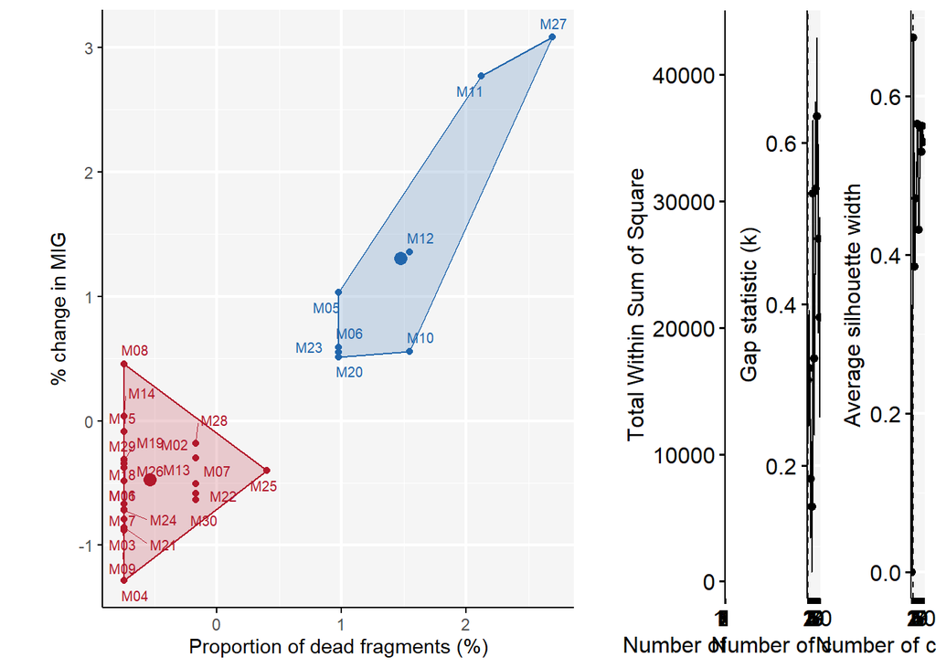

Export.

```r
ggsave(E_individual_kmean_am_all_p,
       filename = '../Results/Figures/E_individual_kmean_am_all_p.png',
       dpi = 900,
       width = 18000,
       height = 4000,
       units = "px")

E_individual_kmean_am_df |>
  write_csv('../Results/Tables/E_individual_kmean_am_df.csv')
```

### 3.4.3 *A. tenuis*

```r
# Edit dataframe to get A. tenuis samples
E_individual_kmean_at_m <-
  D_individual_mort.mig_df |>
  filter(Species == 'A. tenuis') |>
  select(!Species) |>
  column_to_rownames('Colony ID') |>
  as.matrix()

# Optimal cluster checking 1 (wss)
E_individual_kmean_at_wss <-
  fviz_nbclust(E_individual_kmean_at_m,
               kmeans,
               method = "wss",
               k.max = 10,
               linecolor = 'black') +
  theme(plot.title = element_blank(),
        panel.grid = element_blank(),
        strip.background = element_blank(),
        axis.line = element_line(),
        panel.background = element_rect(fill = '#F5F5F5'),
        panel.grid.major.y = element_line(colour = 'white',
                                          linewidth = 0.75),
        panel.grid.minor.y = element_line(colour = 'white',
                                          linewidth = 0.25))

# Optimal cluster checking 2 (gap)
E_individual_kmean_at_gap <-
  fviz_nbclust(E_individual_kmean_at_m,
               kmeans,
               method = "gap",
               nboot=200,
               k.max = 10,
               linecolor = 'black') +
  theme(plot.title = element_blank(),
        panel.grid = element_blank(),
        strip.background = element_blank(),
        axis.line = element_line(),
        panel.background = element_rect(fill = '#F5F5F5'),
        panel.grid.major.y = element_line(colour = 'white',
                                          linewidth = 0.75),
        panel.grid.minor.y = element_line(colour = 'white',
                                          linewidth = 0.25))

# Optimal cluster checking 3 (sillhouette)
E_individual_kmean_at_sil <-
  fviz_nbclust(E_individual_kmean_at_m,
               kmeans,
               method = "silhouette",
               k.max = 10,
               linecolor = 'black') +
  theme(plot.title = element_blank(),
        panel.grid = element_blank(),
        strip.background = element_blank(),
        axis.line = element_line(),
        panel.background = element_rect(fill = '#F5F5F5'),
        panel.grid.major.y = element_line(colour = 'white',
                                          linewidth = 0.75),
        panel.grid.minor.y = element_line(colour = 'white',
                                          linewidth = 0.25))

# Merge plots that check optimal # of clusters
E_individual_kmean_at_opt_p <-
  plot_grid(E_individual_kmean_at_wss,
            E_individual_kmean_at_gap,
            E_individual_kmean_at_sil,
            nrow = 1)

# Make a plot that shows clusters
E_individual_kmean_at_p <-
  E_individual_kmean_at_m |>
  kmeans(centers = 2) |>
  fviz_cluster(E_individual_kmean_at_m,
               labelsize = 8,
               repel = T,
               ylab = '% change in MIG',
               xlab = 'Proportion of dead fragments (%)',
               shape = 16) +
  scale_fill_manual(values = rev(color_htol_c)) +
  scale_color_manual(values = rev(color_htol_c)) +
  coord_fixed() +
  theme(panel.grid = element_blank(),
        plot.title = element_blank(),
        legend.position = 'none',
        strip.background = element_blank(),
        axis.line = element_line(),
        panel.background = element_rect(fill = '#F5F5F5'),
        panel.grid.major.y = element_line(colour = 'white',
                                          linewidth = 0.75),
        panel.grid.minor.y = element_line(colour = 'white',
                                          linewidth = 0.25),
        panel.grid.major.x = element_line(colour = 'white',
                                          linewidth = 0.75),
        panel.grid.minor.x = element_line(colour = 'white',
                                          linewidth = 0.25))

# Extract clusters
E_individual_kmean_at_df <-
  E_individual_kmean_at_m |>
  kmeans(centers = 2) %>%
  .$cluster |>
  as.data.frame() |>
  rownames_to_column() |>
  rename(ColonyID = 1,
         Cluster = 2) |>
  mutate(Cluster = if_else(Cluster == 2,
                                 1,
                                 2)) |>
  mutate(HeatTolerance = if_else(Cluster == 2,
                                 'High',
                                 'Low'))

# Merge plots
E_individual_kmean_at_all_p <-
  plot_grid(E_individual_kmean_at_p,
            E_individual_kmean_at_opt_p,
            ncol = 2,
            rel_widths = c(1,0.5))
```

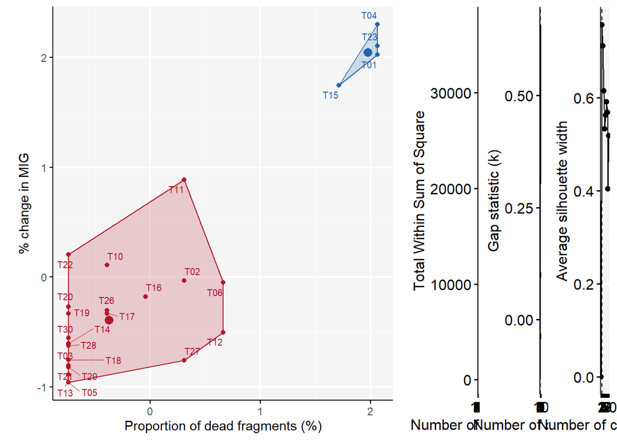

Export.

```r
ggsave(E_individual_kmean_at_all_p,
       filename = '../Results/Figures/E_individual_kmean_at_all_p.png',
       dpi = 900,
       width = 18000,
       height = 4000,
       units = "px")

E_individual_kmean_at_df |>
  write_csv('../Results/Tables/E_individual_kmean_at_df.csv')
```

### 3.4.4 Merge dataframes

```r
E_individual_kmean_merged_df <-
  bind_rows(E_individual_kmean_ad_df,
            E_individual_kmean_am_df,
            E_individual_kmean_at_df) |>
  mutate(Species = case_when(str_detect(ColonyID, 'D') ~ 'A. digitifera',
                             str_detect(ColonyID, 'M') ~ 'A. millepora',
                             str_detect(ColonyID, 'T') ~ 'A. tenuis',
                             .default = NA)) |>
  group_by(Species) |>
  arrange(HeatTolerance,
          .by_group = T)
```

Export.

```r
E_individual_kmean_merged_df |>
  write_csv('../Results/Tables/E_individual_kmean_merged_df.csv')
```

## 3.5 F: Collate rankings

```r
F_individual_coll_htol_df <-
  B_individual_mort_rank_df |>
  ungroup() |>
  select(c(1,5,11,12,13)) |>
  rename('Percent dead' = 3,
         'Survival-based ranking' = 4,
         'Survival-based heat tolerance' = 5) |>
  left_join(C_individual_mig_all_2_df |>
              select(3,1,4,5,6) |>
              rename('Colony' = 2,
                     'Percent MIG change' = 3,
                     'MIG-based ranking' = 4,
                     'MIG-based heat tolerance' = 5)) |>
  left_join(D_individual_mort.mig_std_df |>
              select(1,2,5,6,7) |>
              rename('Colony' = 2,
                     'Combined survival and MIG' = 3,
                     'Survival+MIG-based ranking' = 4,
                     'Survival+MIG-based heat tolerance' = 5)) |>
  left_join(E_individual_kmean_merged_df |>
              select(4,1,2,3) |>
              rename('Colony' = 2,
                     'Kmeans cluster' = 3,
                     'Kmeans-based heat tolerance' = 4))
```

Export.

```r
F_individual_coll_htol_df |>
  write_csv('../Results/Tables/F_individual_coll_htol_df.csv')
```